# Nbconvert: Export notebooks to other formats

Notebook files (`.ipynb`) store your code, notes and output in an editable, executable form. But what if you want to send a notebook to your supervisor, who doesn't have Jupyter installed? Or publish it on your blog?

**Nbconvert** is a tool to convert notebooks to other file formats, such as:

- HTML web pages
- PDF documents (generated by Latex)
- Python scripts (`.py`) which you can run without Jupyter

Nbconvert is integrated into the notebook editor application. If you're reading this in the notebook application, click *File -> Download as*:

[figure not shown]

You can also use nbconvert from the command line:

```
 jupyter nbconvert --to html 'Using Nbconvert.ipynb'
```

Nbconvert is also a Python library, so you can write Python code to convert notebooks. There are [more details in the docs](http://nbconvert.readthedocs.io/en/latest/nbconvert_library.html).

### Challenge 1

Make a `.html` file from this notebook, and open it up in your web browser.

### Challenge 2

Convert the notebook to a format like Markdown, reStructuredText, or LaTeX. What happens to the plot below, which is an image embedded in the notebook?

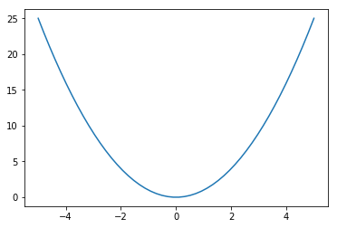

```python
%matplotlib inline
import numpy as np
import matplotlib.pyplot as plt
x = np.linspace(-5, 5)
plt.plot(x, x**2)
# if u want to supress the output of matplotlib, put semicolon
```

### Challenge 3

We've added some metadata to this notebook to divide it up into slides. Can you use nbconvert to make a slideshow?

Use `--help` with command line tools to get more information. You could also [read the docs](http://nbconvert.readthedocs.io/en/latest/index.html) or use a search engine.

```python
!jupyter nbconvert UsingNbconvert.ipynb --to slides --post serve
```

[output not shown]

```python
!jupyter nbconvert --help
```

[output not shown]

[output cut: 72 more lines]

[output not shown]